# Lab 02

May 11, 2020

## Part 1: Loading Data into R

For this portion of the lab, you will load data into R three different ways.

### Method 1 - Built-In Data

Load the `mtcars` data set. This data set is already included in R.

```r
# Write your code below
data(mtcars)
```

Examine, with scatterplots, the relationship between mileage (`mpg`) and:

- displacement (`disp`)
- horsepower (`hp`)
- weight (`wt`)

Note: you may create individual scatterplots for each variable against mileage or you may create one scatterplot matrix using the `pairs()` function.

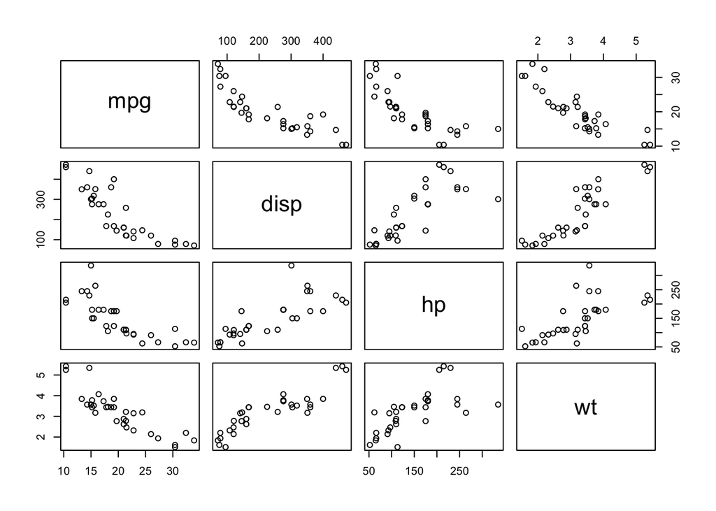

```r
# Write your code below
pairs(~ mpg + disp + hp + wt, data = mtcars)
```

Which variable do you think would be the best linear predictor of a car’s mileage? Why?

Write your answer here.

I think weight is the best linear predictor of a car’s mileage since this variable shows a strong linear relation with mpg. Other varialbes show a bit non-linear attributes.

### Method 2 - Data from an R Package

Load the `brocolli` data set into R from the ‘faraway’ package. You will most likely have to install this package onto your machine first. **Do not install the ‘faraway’ package in your R Markdown file.** This should be done in the console (the command only needs to be run once).

```r
# Write your code below
library(faraway)
data(broccoli)
```

Use the `str()` function to determine how many groups/levels there are for the variable grower.

```r
# Write your code below
str(broccoli)
```

```
## 'data.frame':    36 obs. of  4 variables:
##  $ wt     : num  352 369 383 339 367 328 376 359 388 365 ...
##  $ grower : Factor w/ 3 levels "1","2","3": 1 1 1 2 2 2 3 3 3 1 ...
##  $ box    : Factor w/ 4 levels "1","2","3","4": 1 1 1 1 1 1 1 1 1 2 ...
##  $ cluster: Factor w/ 3 levels "1","2","3": 1 2 3 1 2 3 1 2 3 1 ...
```

How many groups/levels are there for the variable grower?

Write your answer here.  
There are 3 levels for the variable grower.

Create one side-by-side boxplot for the variable weight comparing the various growers.

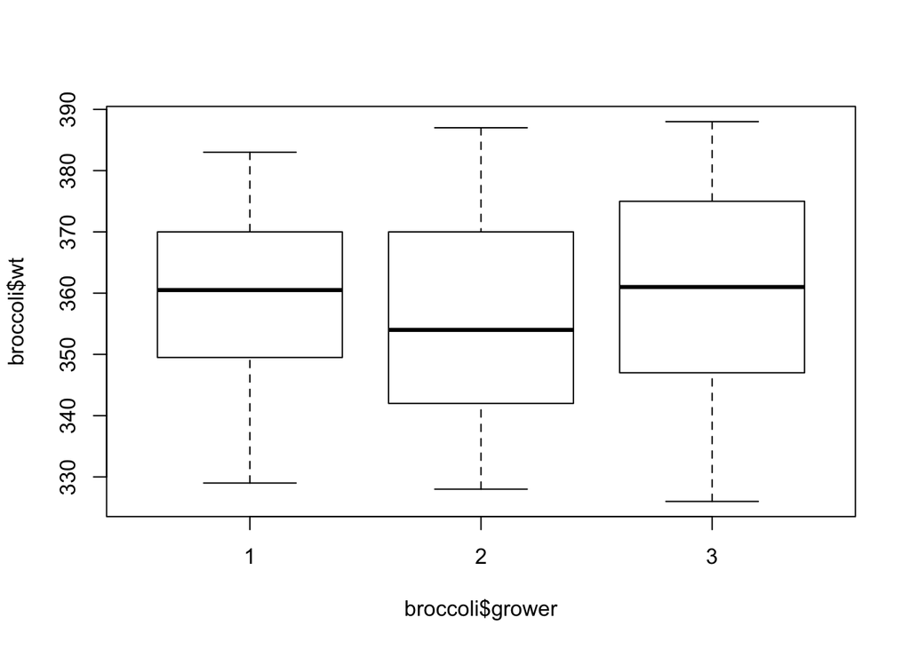

```r
# Write your code below
boxplot(broccoli$wt ~ broccoli$grower)
```

### Method 3 - Data from an Outside Source

Download the “Pokemon.csv” data set from Canvas and load it into R.

```r
# Write your code below
df=read.csv('pokemon.csv',header = TRUE)
```

Use the `head()` function to display the first 6 rows of data.

```r
# Write your code below
head(df)
```

```
##   X.                  Name Type.1 Type.2 Total HP Attack Defense Sp..Atk
## 1  1             Bulbasaur  Grass Poison   318 45     49      49      65
## 2  2               Ivysaur  Grass Poison   405 60     62      63      80
## 3  3              Venusaur  Grass Poison   525 80     82      83     100
## 4  3 VenusaurMega Venusaur  Grass Poison   625 80    100     123     122
## 5  4            Charmander   Fire          309 39     52      43      60
## 6  5            Charmeleon   Fire          405 58     64      58      80
##   Sp..Def Speed Generation Legendary
## 1      65    45          1     False
## 2      80    60          1     False
## 3     100    80          1     False
## 4     120    80          1     False
## 5      50    65          1     False
## 6      65    80          1     False
```

Using the `table()` function, determine how many of the 800 Pokemon are listed as “Water” for the Type.1 variable.

```r
# Write your code below
table(df$Type.1)
```

```
##
##      Bug     Dark   Dragon Electric    Fairy Fighting     Fire   Flying
##       69       31       32       44       17       27       52        4
##    Ghost    Grass   Ground      Ice   Normal   Poison  Psychic     Rock
##       32       70       32       24       98       28       57       44
##    Steel    Water
##       27      112
```

How many Pokemon are listed as “Water”?

## Part 2: Calculating the Estimated Regression Coefficients

For this portion of the lab, you will calculate estimated regression coefficients three different ways. For all three methods, we will use the `mtcars` data set. You can find more information about the data set by running `help(mtcars)` in your console.

### Method 1 - Simple Linear Reression (Manually)

Find the estimated coefficients for a simple linear regression model without using the `lm()` function.

Calculate $\hat{\beta}_1$ and $\hat{\beta}_0$ for the model predicting mileage (`mpg`) based on weight (`wt`). Do not use R’s modeling capabilities (i.e. the `lm()` function). Rather, use R as a calculator to help with the computations. Hint: Check out the Lab02 Example.

```r
# Write your code below
y=mtcars$mpg
x=mtcars$wt

ssxx <- sum((x - mean(x))^2)
ssxy <- sum((x - mean(x)) * (y - mean(y)))

beta.hat.1 <- ssxy / ssxx
beta.hat.0 <- mean(y) - (beta.hat.1 * mean(x))

beta.hat.0; beta.hat.1
```

```
## [1] 37.28513
```

```
## [1] -5.344472
```

Interpret your results for $\hat{\beta}_1$ within the context of the problem. Be careful with units.

Write your answer here.

For a 1000 lbs weight increase, we would estimate an average decrease of 5.344472 miles/gallon in mpg.

Create a plot of mileage and weight. Then, using the abline() function, add your regression line to the plot. Be sure to give your plot proper labels for the axes.

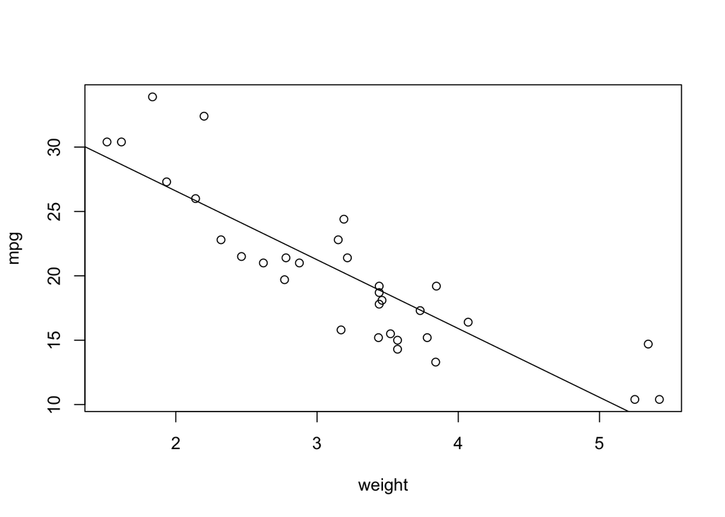

```r
# Write your code below
plot(x, y, xlab = 'weight', ylab = 'mpg')
abline(a = beta.hat.0, b = beta.hat.1)
```

### Method 2 - Multiple Linear Regression (Matrices)

Find the estimated coefficients for a multiple linear regression model using matrices. You will attempt to predict the mileage of a car (`mpg`) based upon several predictors

Generate your design matrix, $X$. The design matrix is a column of 1’s (for the intercept) followed by a column for each predictor. Use the following predictors:

- displacement (`disp`)
- horsepower (`hp`)
- weight (`wt`)

Note: While you may generate this manually if you want, an easier way to do this is using the `model.matrix()` function. Check out the Lab02 Example.

```r
# Write your code below
X <- model.matrix( ~ disp + hp + wt, data = mtcars)
Y = mtcars$mpg
```

Calculate $\hat{\beta}$. Recall that in class we derived $\hat{\beta}=(X^TX)^{-1}X^TY$.

```r
# Write your code below
beta.hat <- solve(t(X) %*% X) %*% (t(X) %*% Y)
beta.hat
```

```
##                      [,1]
## (Intercept) 37.1055052690
## disp        -0.0009370091
## hp          -0.0311565508
## wt          -3.8008905826
```

(Optional) Challenge: estimate $\sigma^2$ by calculating the fitted values and then the residuals.

```r
# Write your code below
```

### Method 3 - Confirmation of the Estimated Coefficients

Confirm the estimated coefficients from Method 1 and Method 2 using the `lm()` function.

Using the `lm()` function, create the simple linear regression model predicting mileage (`mpg`) based on weight (`wt`). Do the results match the values calculated using Method 1?

```r
# Write your code below
lm(mpg~wt, data=mtcars)
```

```
##
## Call:
## lm(formula = mpg ~ wt, data = mtcars)
##
## Coefficients:
## (Intercept)           wt
##      37.285       -5.344
```

The results match the values calculated using Method 1.

Using the `lm()` function, create the multiple linear regression model predicting mileage (`mpg`) based on displacement (`disp`), horsepower (`hp`), and weight (`wt`). Do the results match the values calculated using Method 2?

```r
# Write your code below
lm(mpg ~ disp+hp+wt, data=mtcars)
```

```
##
## Call:
## lm(formula = mpg ~ disp + hp + wt, data = mtcars)
##
## Coefficients:
## (Intercept)         disp           hp           wt
##   37.105505    -0.000937    -0.031157    -3.800891
```

The results match the values calculated using Method 2.

Store the multiple linear regression model and pass it through the `summary()` function. Which of the variables are statistically significant linear predictors at a 5% significance level?

```r
# Write your code below
mlr=lm(mpg ~ disp+hp+wt, data=mtcars)
summary(mlr)
```

```
##
## Call:
## lm(formula = mpg ~ disp + hp + wt, data = mtcars)
##
## Residuals:
##    Min     1Q Median     3Q    Max
## -3.891 -1.640 -0.172  1.061  5.861
##
## Coefficients:
##              Estimate Std. Error t value Pr(>|t|)
## (Intercept) 37.105505   2.110815  17.579  < 2e-16 ***
## disp        -0.000937   0.010350  -0.091  0.92851
## hp          -0.031157   0.011436  -2.724  0.01097 *
## wt          -3.800891   1.066191  -3.565  0.00133 **
## ---
## Signif. codes:  0 '***' 0.001 '**' 0.01 '*' 0.05 '.' 0.1 ' ' 1
##
## Residual standard error: 2.639 on 28 degrees of freedom
## Multiple R-squared:  0.8268, Adjusted R-squared:  0.8083
## F-statistic: 44.57 on 3 and 28 DF,  p-value: 8.65e-11
```

Which predictor variables are statistically significant?

Write your answer here. hp and wt are statistically significant